# Final Project Draft

Aidan Godfrey, Irene Zhang, Benjamin Lewis

4/21/2020

## Background

### What is the purpose of the project?

- Our analysis will be heavily based on grouping the data and seeing if the person uses their dominant hand or non-dominant hand more often
- We are studying two cases of wether over ten (10) seperate mealtimes with Irene Zhang’s parent, how often do they touch there face with their dominant and non-dominant hand?

#### Goal: We want to see, in general, what hand are they more likely to use to touch their face? The dominant or non-dominant hand?

## Project outlook

- We want to see what hand a person uses to touch their face more often
- This can be important in terms of a virus spreading, in that if someone uses their dominant hand to use things, then they touch there faces, viruses may spread at higher rates
- We will look at the total times two memberes of Irene’s Family touches their face
- We will group them together to make a statment of wether a person in genereal use their dominant.

> Null Hypothesis: H0 – There is no difference in the difference between the proportion of what hand is used to touch someone’s face (p dominant == p non-dominant).

> Alternative Hypothesis: HA – There is a difference in the proportion of what hand is used to touch someone’s face (p dominant != p non-dominant).

## Data at a Glance

### Orignial Data

We included two tables of data, one shows the **total amount of touches of each parent** on a specific date (Month.Day). (DH = Dominant Hand)

The second one shows the **number of touches with the dominant hand** done by the person on the specific date.

```
##            4.7 4.8 4.9 4.11 4.13 4.14 4.16 4.18 4.19 4.20
## All Father   2   5   3    3    6    4    4    3    2    3
## All Mother   0   4   3    1    2    2    3    2    0    1
```

```
##           4.7 4.8 4.9 4.11 4.13 4.14 4.16 4.18 4.19 4.20
## DH Father   2   4   3    2    4    2    2    2    1    2
## DH Mother   0   4   3    1    1    2    2    2    0    0
```

### Summarized Data

Here, the table summarizing each person, mother or father, and the total counts and which hand was used.

```
##          Father Mother
## Total        35     18
## Dom Hand     24     15
```

This table is the mother and father grouped together comparing the combined total number of face touches and the number of touches done with the dominant hand.

```
##          Father and Mother
## Total                   53
## Dom Hand                39
```

### Count of Hand Touching at a Glance

In this graph, one can see two things. Both parents touched their face with the dominant hand more often, espically the mother. Also, The father touched his hands nearly 2X as much as the mother.

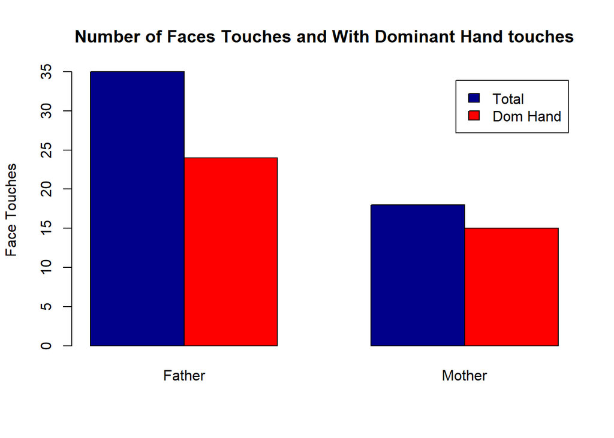

## Data Analysis

Here, we will only adress the first hypothesis observed by pooling the mother and father data together to see as a sample of two people.

### Are they more likely to touch their face with their dominant hand or not?

First, we will assume independence between each person, the mother and father, and grouped them to get a more representative sample and larger n size.

Next, We know for the success and failure rate to be greater than 10 for dominant and non-dominant hand touching.

### Test Statistic

Therefore, we can proceed for a test of a single proportion under the assumption of the null hypothesis.

#### P-Hat (Dominant Hand Touches / Total Hand Touches)

```
## [1] 0.736
```

The proportion is the percentage of times the mother or father used their dominant hand.

### Z-Score and P-value

Now, we calculate the p-value using a z-score test under the null hypothesis.

First we calculate the z-score.

```
## [1] 3.43
```

The Z-score is 3.43, which if graphed as shown below, is rather unlikely

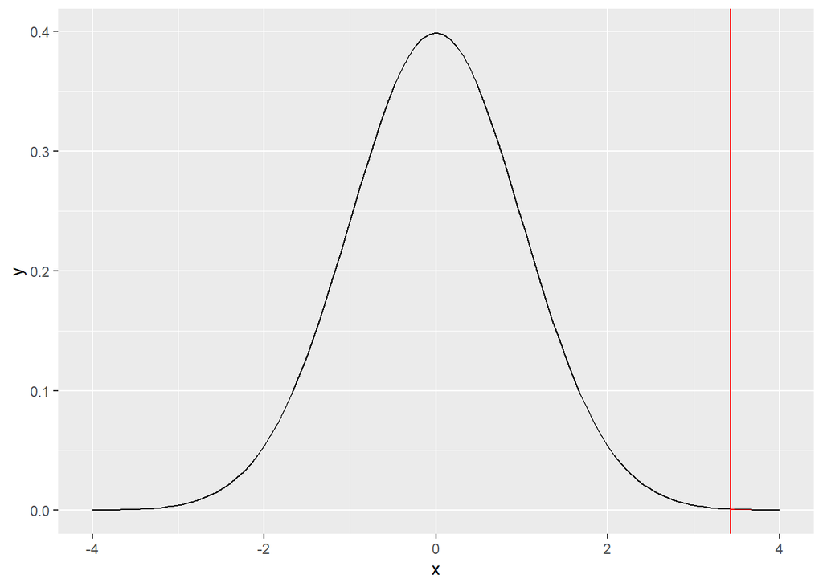

```
## [1] 0.00059
```

The p-value is exteremly small at 0.00059, which is rather unlikely as seen on the graph.

### Interpretation

Our p-value is stastically significnat (p=0.00059, two-sided z-test for a single proportion) so **we reject the null hypothesis.**

There is evidence that the parents touch their face with their dominant hand more than half the time. This is not represenative of the entire population at a whole, as stated with our possible improvments below, but it allows us to see that in the case of two people, the dominant hand is certainly used more often.

### Potential Improvment

Some improvments to the experiement would be as stated below:

- Gather a much larger sample size around a wide variety of people
  - Wathcing two people alone is not represenative of the whole population whatesoever, but gives us a clue into a reasonable conjecture.
  - A variety of left handers and right handers are needed, perhaps a specific hand is more likely independent of what the dominant hand is. In our expierement the Father was right-handed and the Mother was left-handed.
  - This family might touch their face less often due to the current health climate, or just personal family tendicies
- Track across multiple sample times since restricting oneself to the dinner time is not represenative.
  - Being self-concious around others, eating and spilling food, and behavioral factors could affect how often one touches there face at dinner
  - Outside of mealtimes, while it would be more difficult to study in a blind study, but it would be more represenatative.